**Yearly Trends**

I will now show different visualizations on the trends of elevation with temperature and snow depth: some with early and late season snowfall. This will help us see how weather affects the different elevations.

High Temperature

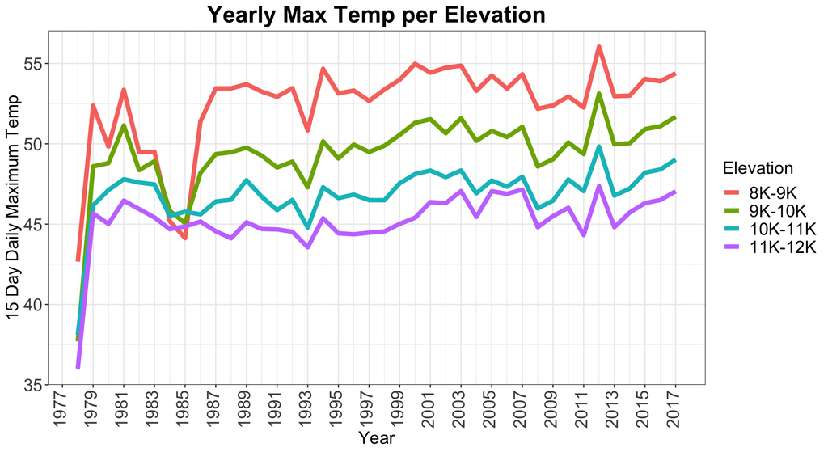

A slightly positive trend is developing. Also interesting to note how the difference in temperature between the elevations remains pretty proportional as well.

Low Temperature

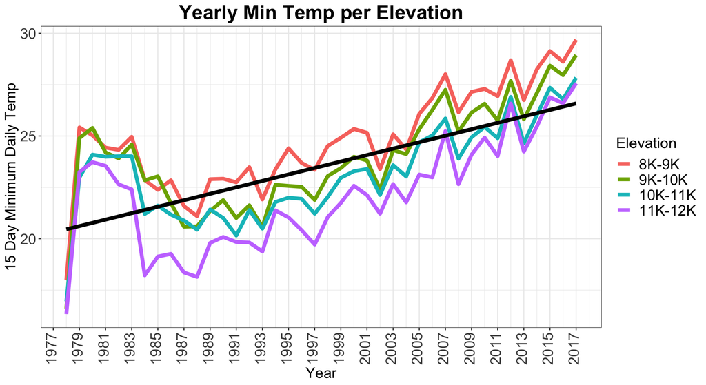

This one I find alarming. Average yearly low temperatures are increasing steadily, and the gap between 11500 and 11000 stations is also closing. This means temperature disparity is decreasing, which might affect ecology at certain levels as well.

Low Temperature by Season

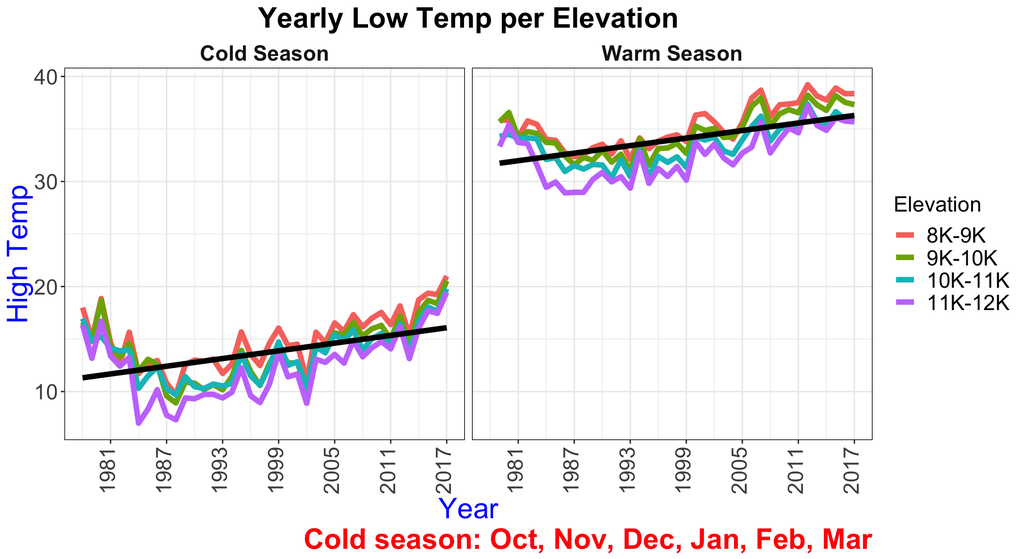

This shows us that the 15 day low increaes just about the same in either coldest or warmest 6-month periods.

Daily High to Low Proportion

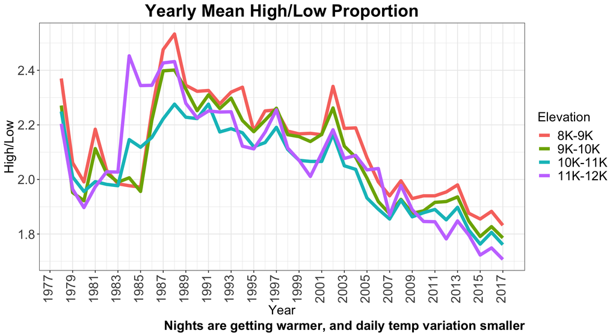

May Snowpack

The following shows the elevation yearly trends in **May**. I chose May because it’s a pivotal month where a lot of the snowpack disappears because of warming temperatures, and maybe this a month where global warming could highly impact.

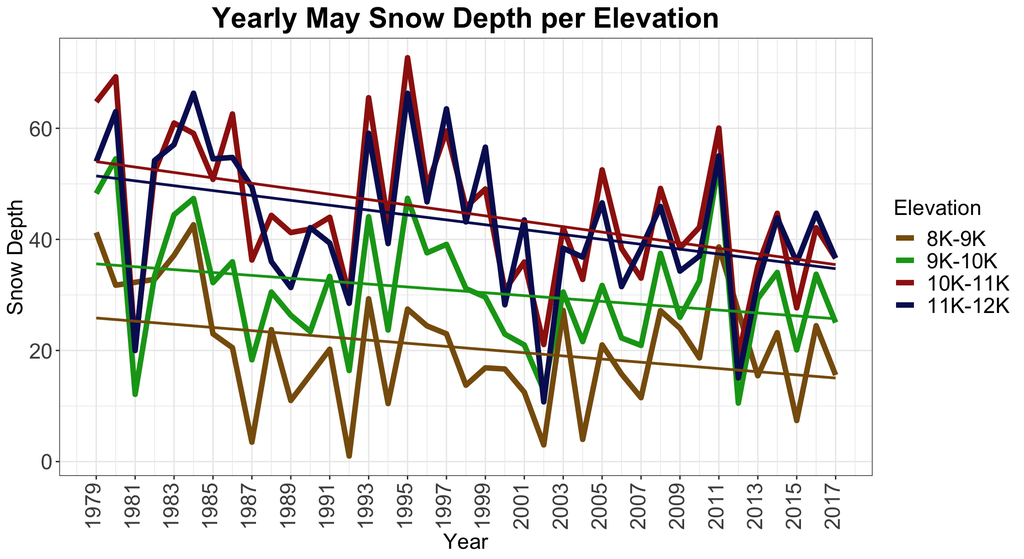

An overall negative trend is observed, with very little variation within elevations.

November Snowpack

I chose **November** for the same reason: it’s a month where snowpack can steadily increase, some that perhaps global warming will delay.

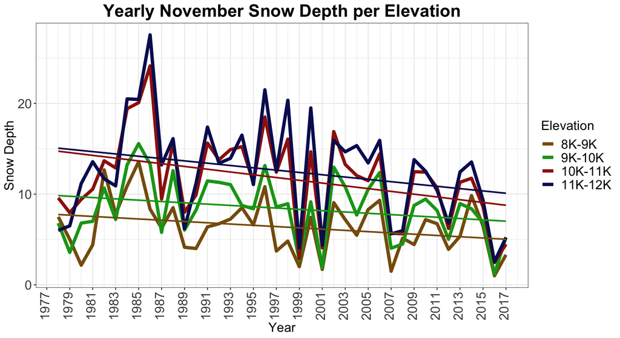

We are observing more of the same. An overall decreased trend with little variation within month.